# Ch6

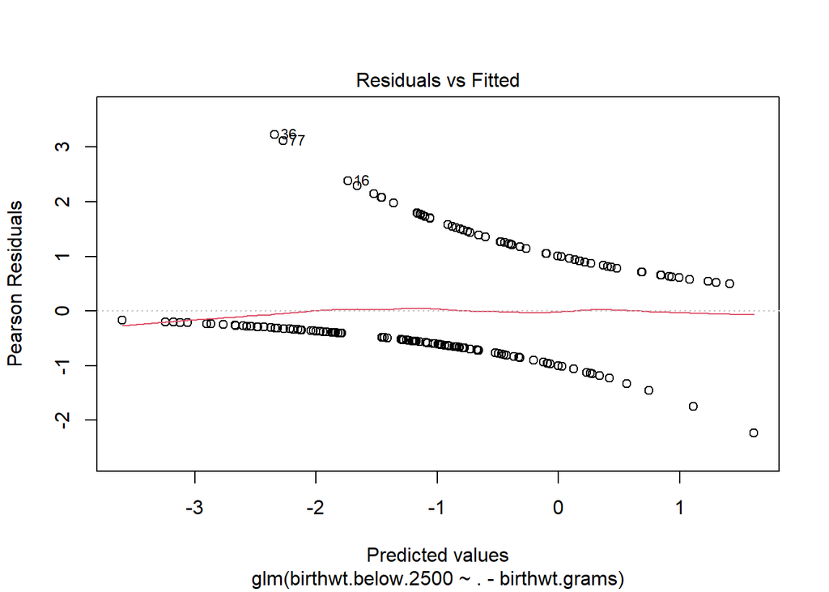

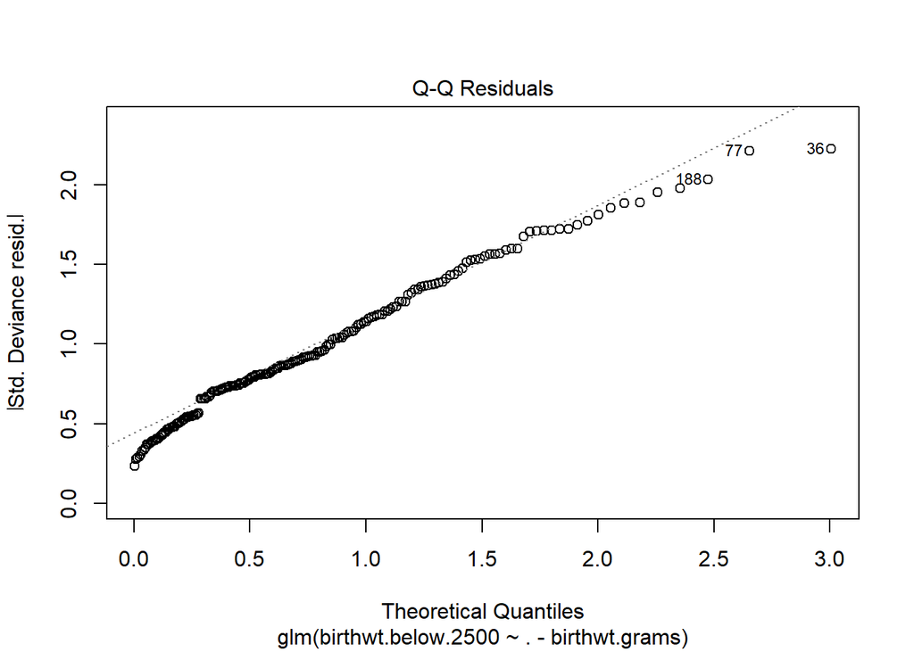

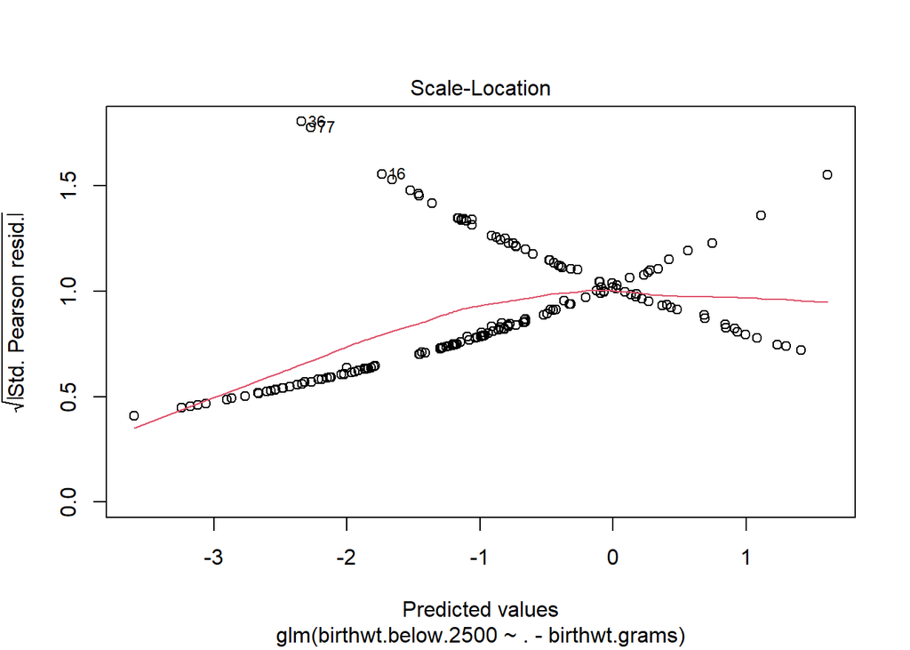

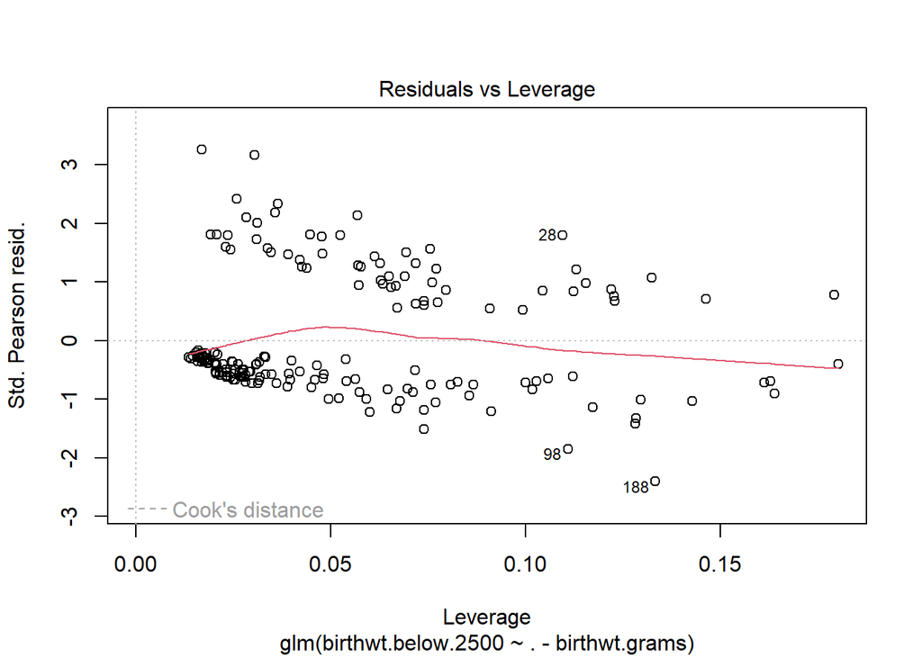

```r
plot(glm.1)
```

#### What Do We Do With This, Anyway?

Let’s take a subset of this data to do predictions.

```r
odds <- seq(1, nrow(birthwt.noout), by=2)
birthwt.in <- birthwt.noout[odds,]
birthwt.out <- birthwt.noout[-odds,]
linear.model.half <- lm (birthwt.grams ~ . - birthwt.below.2500, data=birthwt.in)
summary (linear.model.half)
```

```
##
## Call:
## lm(formula = birthwt.grams ~ . - birthwt.below.2500, data = birthwt.in)
##
## Residuals:
##      Min       1Q   Median       3Q      Max
## -1705.17  -303.11    26.48   427.18  1261.57
##
## Coefficients:
##                     Estimate Std. Error t value Pr(>|t|)
## (Intercept)         2514.891    450.245   5.586 2.81e-07 ***
## mother.age             7.052     14.935   0.472  0.63801
## mother.weight          2.683      2.885   0.930  0.35501
## raceother            113.948    224.519   0.508  0.61312
## racewhite            466.219    204.967   2.275  0.02548 *
## mother.smokesYes    -217.218    154.521  -1.406  0.16349
## previous.prem.labor -206.093    143.726  -1.434  0.15530
## hypertensionYes     -653.594    281.795  -2.319  0.02280 *
## uterine.irrYes      -547.884    193.386  -2.833  0.00577 **
## physician.visits    -130.202     81.400  -1.600  0.11346
## ---
## Signif. codes:  0 '***' 0.001 '**' 0.01 '*' 0.05 '.' 0.1 ' ' 1
##
## Residual standard error: 643.7 on 84 degrees of freedom
## Multiple R-squared:  0.2585, Adjusted R-squared:  0.1791
## F-statistic: 3.254 on 9 and 84 DF,  p-value: 0.001942
```

```r
birthwt.predict <- predict (linear.model.half)
cor (birthwt.in$birthwt.grams, birthwt.predict)
```

```
## [1] 0.508442
```

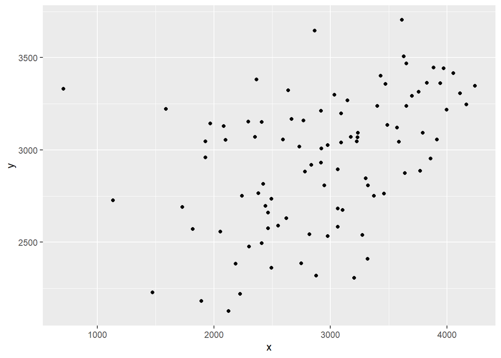

```r
tibble(x = birthwt.out$birthwt.grams, y = birthwt.predict) |>
  ggplot (aes(x = x, y = y)) + geom_point()
```

```r
birthwt.predict.out <- predict (linear.model.half, birthwt.out)
cor (birthwt.out$birthwt.grams, birthwt.predict.out)
```

```
## [1] 0.3749431
```

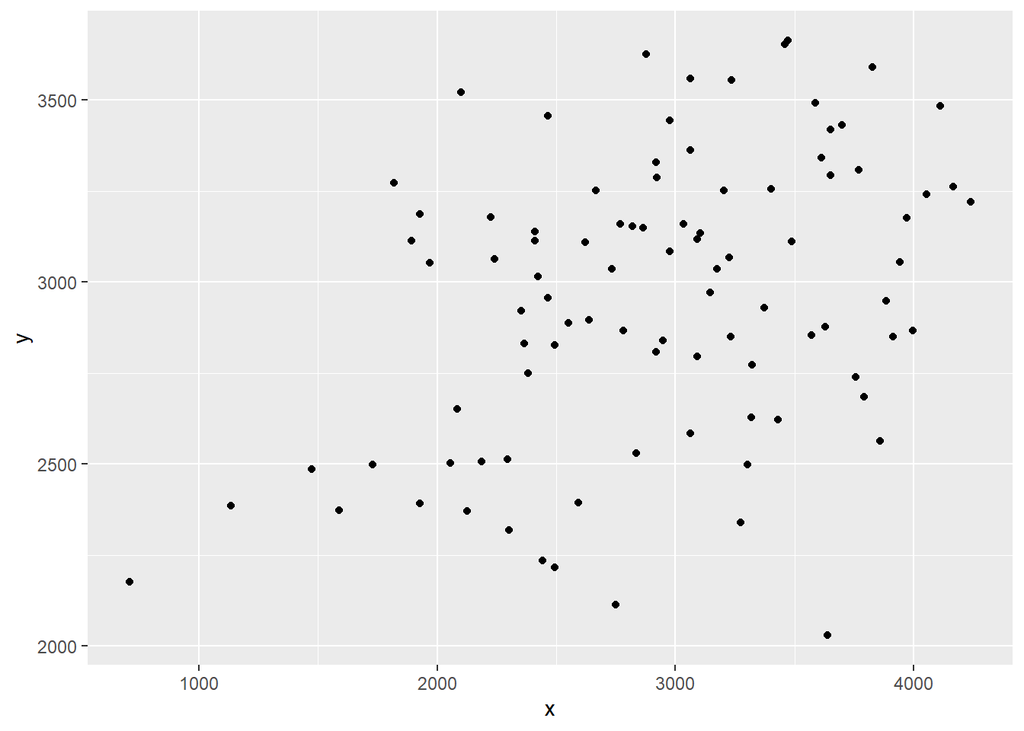

```r
tibble(x = birthwt.out$birthwt.grams, y = birthwt.predict.out) |>
  ggplot (aes(x = x, y = y)) + geom_point()
```

## Random number generators

Example: runif, where we know where it started

```r
runif(1:10)
```

```
##  [1] 0.51660733 0.79113308 0.88694858 0.95988737 0.02976759 0.36492795
##  [7] 0.05283102 0.35203489 0.72952322 0.46235801
```

```r
set.seed(10)
runif(1:10)
```

```
##  [1] 0.50747820 0.30676851 0.42690767 0.69310208 0.08513597 0.22543662
##  [7] 0.27453052 0.27230507 0.61582931 0.42967153
```

#### Basic version: Linear Congruential Generator

```r
seed <- 10
new.random <- function (a=5, c=12, m=16) {
  out <- (a*seed + c) %% m
  seed <<- out
  return(out)
}
out.length <- 20
variates <- rep (NA, out.length)
for (kk in 1:out.length) variates[kk] <- new.random()
variates
```

```
##  [1] 14  2  6 10 14  2  6 10 14  2  6 10 14  2  6 10 14  2  6 10
```

Try again. Period 8:

```r
variates <- rep (NA, out.length)
for (kk in 1:out.length) variates[kk] <- new.random(a=131, c=7, m=16)
variates
```

```
##  [1]  5  6  9  2 13 14  1 10  5  6  9  2 13 14  1 10  5  6  9  2
```

Try again, again. Period 16:

```r
variates <- rep (NA, out.length)
for (kk in 1:out.length) variates[kk] <- new.random(a=129, c=7, m=16)
variates
```

```
##  [1]  9  0  7 14  5 12  3 10  1  8 15  6 13  4 11  2  9  0  7 14
```

Try again, at last. Numerical Recipes uses:

```r
variates <- rep (NA, out.length)
for (kk in 1:out.length) variates[kk] <- new.random(a=1664545, c=1013904223, m=2^32)
variates
```

```
##  [1] 1037207853 2090831916 4106096907  768378826 3835752553 1329121000
##  [7] 2125006663 2668506502 3581687205 2079234980 2067291011 2197025090
## [13] 3748878561 2913996384  758844863 4029469438 2836748829 1458315036
## [19] 2399149563 2766656186
```

## A few distributions of interest:

Uniform(0,1)  
Bernoulli(p)  
Binomial(n,p)  
Gaussian(0,1)  
Exponential(1)  
Gamma(a)

## Suppose we were working with the Exponential distribution.

#### rexp() generates variates from the distribution.

```r
rexp(0:5)
```

```
## [1] 0.3033113 0.1354755 2.3276229 0.7291238 1.2883101 0.6722683
```

#### dexp() gives the probability density function.

```r
dexp(0:5)
```

```
## [1] 1.000000000 0.367879441 0.135335283 0.049787068 0.018315639 0.006737947
```

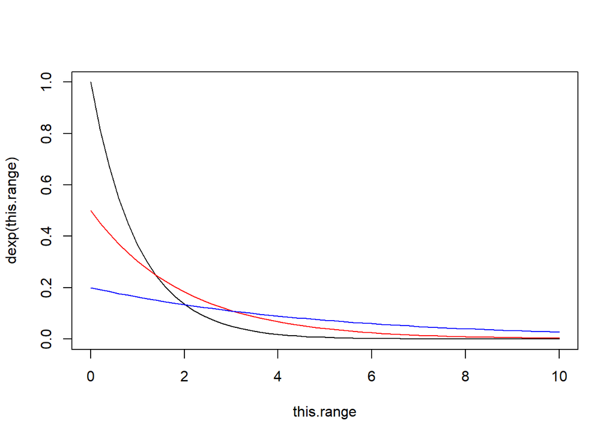

```r
this.range <- 0:50/5
plot (this.range, dexp(this.range), ty="l")
lines (this.range, dexp(this.range, rate=0.5), col="red")
lines (this.range, dexp(this.range, rate=0.2), col="blue")
```

#### pexp() gives the cumulative distribution function.

```r
pexp(0:5)
```

```
## [1] 0.0000000 0.6321206 0.8646647 0.9502129 0.9816844 0.9932621
```

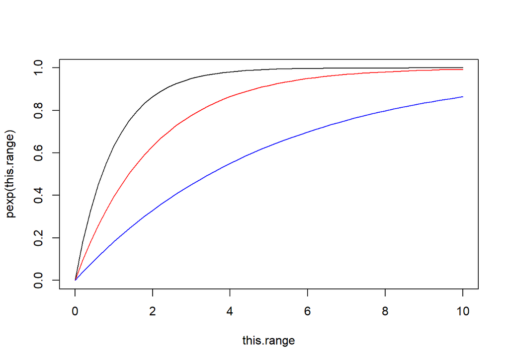

```r
this.range <- 0:50/5
plot (this.range, pexp(this.range), ty="l")
lines (this.range, pexp(this.range, rate=0.5), col="red")
lines (this.range, pexp(this.range, rate=0.2), col="blue")
```

#### qexp() gives the quantiles.

```r
qexp(0:5)
```

```
## [1]   0 Inf NaN NaN NaN NaN
```

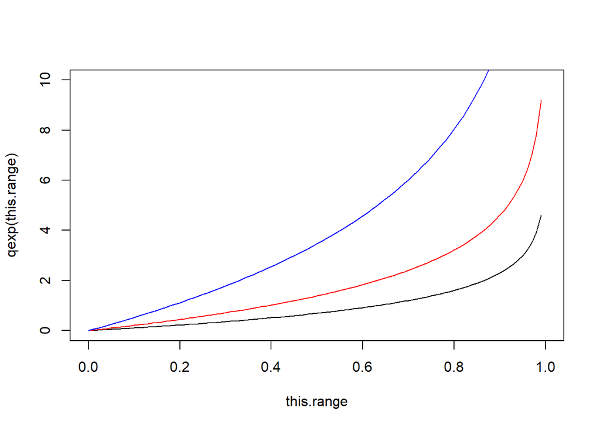

```r
this.range <- seq(0,1,by=0.01)
plot (this.range, qexp(this.range), ylim = c(0, 10), ty="l")
lines (this.range, qexp(this.range, rate=0.5), col="red")
lines (this.range, qexp(this.range, rate=0.2), col="blue")
```

## S&P 500

The Standard and Poor’s 500, or simply the S&P 500, is a stock market index tracking the stock performance of 500 large companies listed on exchanges in the United States. It is one of the most commonly followed equity indices.

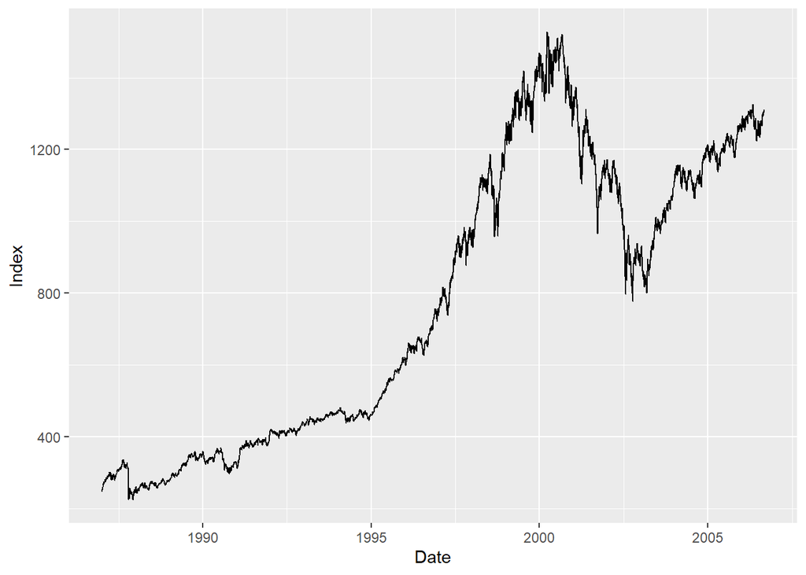

```r
library(readxl)
SP <- read_excel("data/Stock_Bond.xls") |> dplyr::select(Date, `S&P_AC`) |>
  rename(Index = `S&P_AC`)
SP |> ggplot(aes(x = Date, y = Index)) + geom_line()
```

The price $p_t$ doesn’t matter, what matters are the returns $r_t=log(p_t/p_{t-1})$

```r
returns <- na.omit(as.vector(diff(log(SP$Index))))
summary(returns)
```

```
##       Min.    1st Qu.     Median       Mean    3rd Qu.       Max.
## -0.2289972 -0.0046537  0.0004976  0.0003368  0.0056195  0.0870888
```

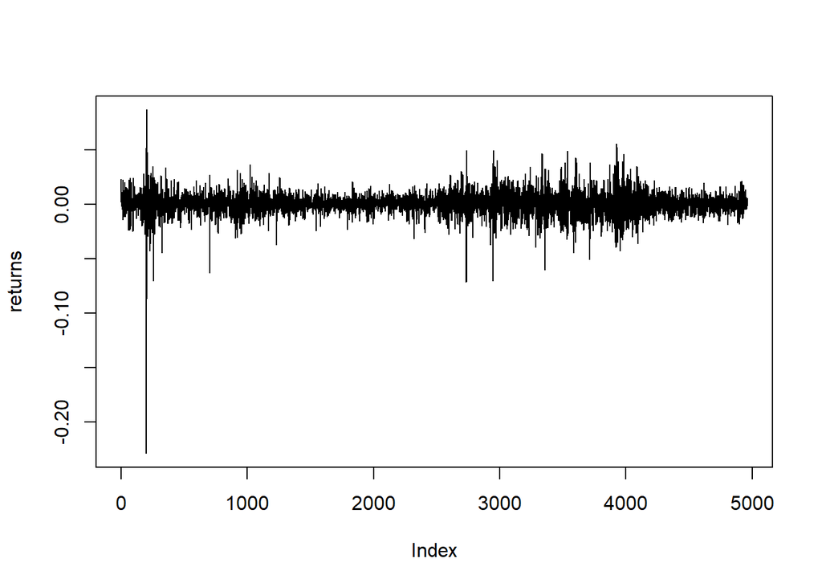

```r
plot(returns, type="l")
```

## The Data’s Distribution #### quantile(x,probs) calculates the quantiles at probs from x.

```r
quantile(returns,c(0.25,0.5,0.75))
```

```
##           25%           50%           75%
## -0.0046537538  0.0004976042  0.0056195438
```

#### ecdf() - e mpirical c umulative d istribution f unction; no assumptions but also no guess about distribution between the observations.

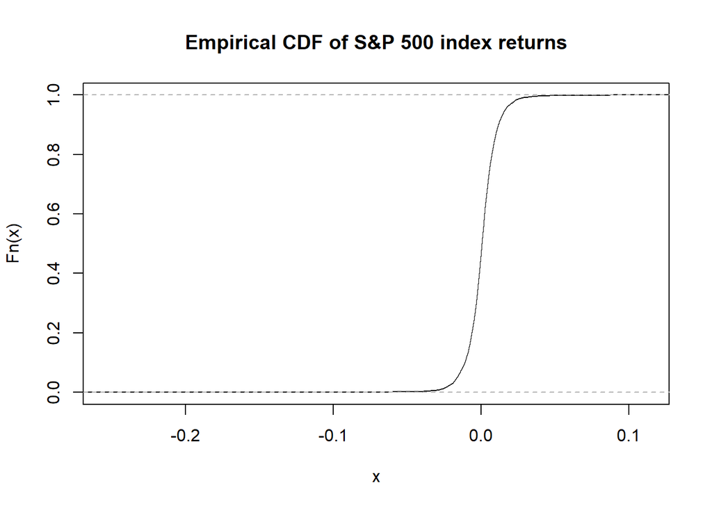

```r
plot(ecdf(returns), main="Empirical CDF of S&P 500 index returns")
```

Conceptually, quantile and ecdf are inverses to each other.

## Getting Probability Densities from Data

ist(x) calculates a histogram from x.  
divide the data range up into equal-width bins and count how many fall into each bin.  
Or divide bin counts by (total count)*(width of bin), and get an estimate of the probability density function (pdf).

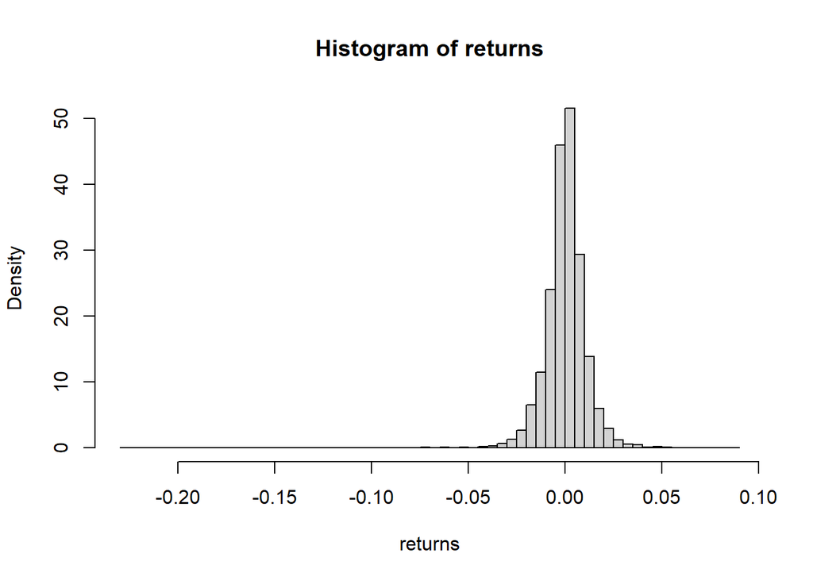

```r
hist(returns,n=101,probability=TRUE)
```

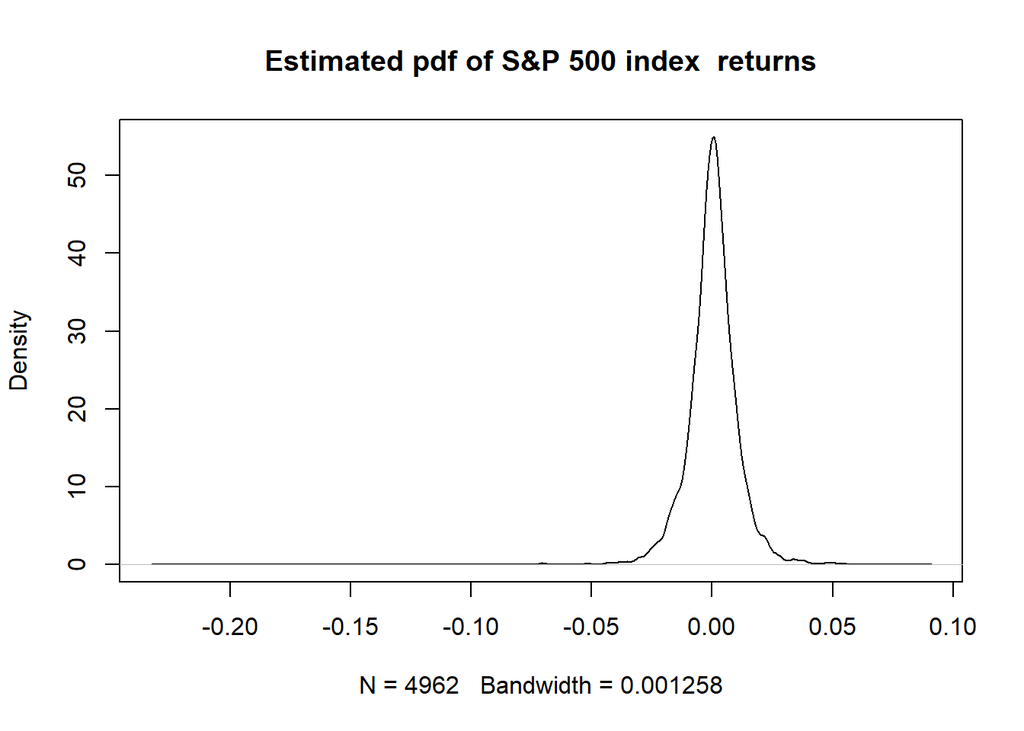

```r
plot(density(returns),main="Estimated pdf of S&P 500 index  returns")
```

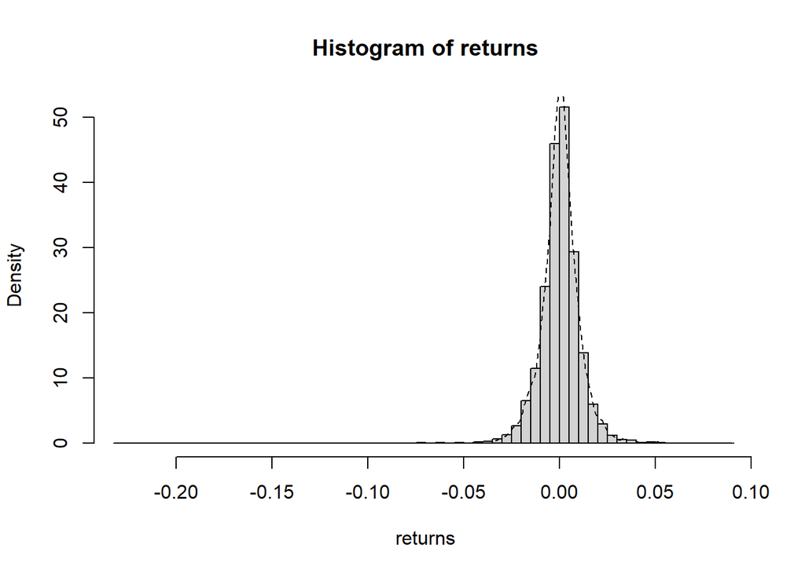

```r
hist(returns,n=101,probability=TRUE)
lines(density(returns),lty="dashed")
```

table() - tabulate outcomes, most useful for discrete spaces; remember to normalize if you want probabilities.

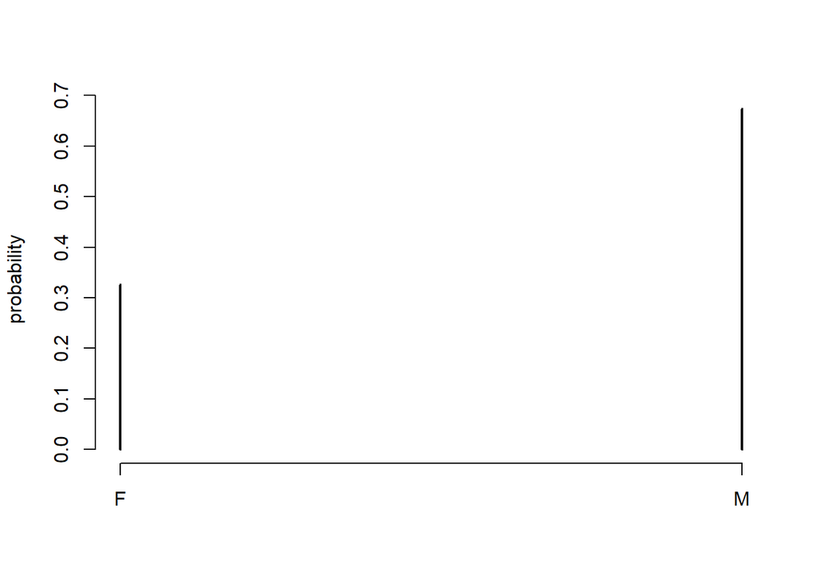

```r
plot(table(cats$Sex)/nrow(cats),ylab="probability")
```

## R commands for distributions dfoo = the probability d ensity (if continuous) or probability mass function of foo (pdf or pmf)  
pfoo = the cumulative p robability function (CDF)  
qfoo = the q uantile function (inverse to CDF)  
rfoo = draw r andom numbers from foo (first argument always the number of draws)  
?Distributions to see which distributions are built in.

## Displaying Probability Distributions

curve is very useful for the d, p, q functions:

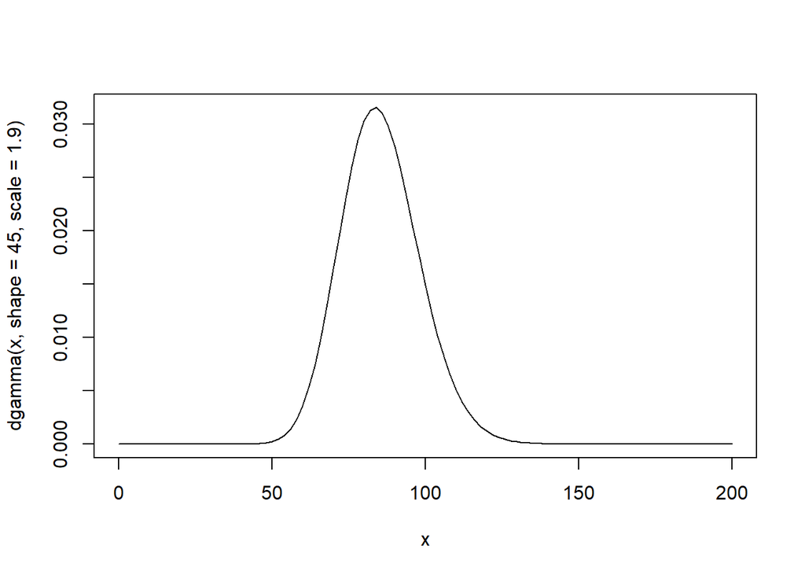

```r
curve(dgamma(x,shape=45,scale=1.9),from=0,to=200)
```